# Key Readings Summaries

Jody Holland

# Preface

This document is to serve as a selection of summaries of literature that I regard as potentially very related to the research themes in this project.

## (Santos et al. 2005)

This paper from 2005 relates to research from Brazil in 2003. Based in the south of Brazil the aim of this research was threefold. The researchers aimed to determine the characteristics of people who engage in littering, as well as the perceptions of people to the problem of litter on the beach. To achieve this they used a mix of qualitative and quantitative methods, including handing out a survey to beach visitors, sampling the characteristics of visitors to the beaches over a period of time, and sampling the level of litter on the beaches over the same period of time. The results indicated that people’s primary concern was relating to the dangers to humans caused by littering. They also found that when a beach was visted by increased levels of low-income and low-education people, the levels of litter increased relative to the base line.

In my opinion this research is limited to not exploring if national background caused differentiation in littering behaviour, it is potentially outdated, the statistical modelling is very simplistic (bivariate regression), and more beaches could be surveyed. However, this paper does get bonus points for including the best visulisation I have seen in a while.

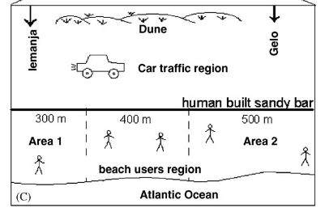

(Santos et al. 2005)

## (Kedzierski et al. 2020)

This review paper goes over the existing literature on why people may leave litter in the environment. It also looks at the history of anti-littering interventions, evaluating the success and failure of such measures. I think the utility of this paper is found in its ability to contextualise the problem of littering in plain terms. Furthermore, this paper can serve as a good basis to find more specific research on the topic, through looking at the other work it cites. They do end the paper on the rather somber note, emphasising the urgency of research and policy on this issue:

*“Our descendants will have to face a daunting legacy and will seek the reasons why we were unable to find strategies to effectively solve the problem of plastic end of life.”* (Kedzierski et al. 2020, 8)

## (Li et al. 2018)

This paper explores the new trend of working with “big data” in tourism research. An emerging field of study in the 21st century, big data relates to the hitherto unimaginable amount of scale of datasets gathered from contemporary digital information, such as GPS information. For tourism studies, the authors the trend of papers published using “big data” and breakdown the types of data used in these studies. For instance, and potentially relevant to this research, they find that around 22% of all studies employed GPS tracking data to study mobility trends in the tourism industry. The largest category of data is UGC or “User Generated Content” like online reviews (it may be possible to explore this too by scraping review sites on the beaches for reference to litter).

Going into more detail on the use of GPS data, they provide this helpful info-graphic:

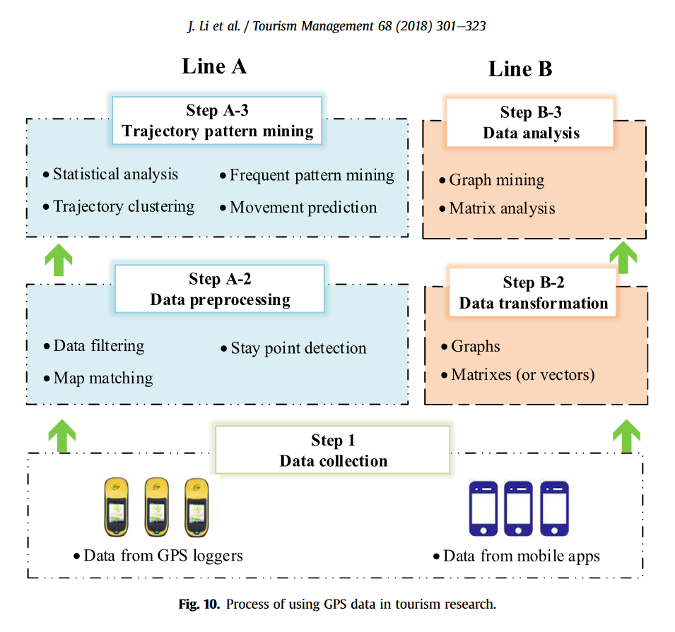

(Li et al. 2018)

In my opinion, this paper is an invaluable guide for me during this project. Notably, its insights and references to studies employing a variety of data collection and wrangling techniques within tourism studies is extremely compelling to me. It is my hope that I will be able to marry this study to the field of garbage research. Moreover, for writing any research proposal, I feel as if this paper could form a formidible backbone upon which to outline a methodology

## (Araújo and Costa 2019)

At the time of this paper’s publication, the authors note that annually “4.5 trillion cigarettes are littered in the environment.” To this end, the authors present a literature review of the existing research addressing the topic of cigarrette butt pollution in the coastal environments of the world.

The authors discuss the mechanisms behind the impact of cigarette butt pollution on the environment, noting that cigarette butts can leach toxic chemicals into the water, affect the growth of plants and animals, and even cause physical harm to marine life that mistake them for food. The authors also discuss the aesthetic impact of cigarette butt pollution, noting that it can detract from the natural beauty of coastal environments and impact the tourism industry.

The authors then evaluate current efforts to address the problem of cigarette butt pollution in coastal environments. They highlight the fact that many jurisdictions have implemented laws and regulations aimed at reducing cigarette butt littering, but note that enforcement can be challenging. The authors also discuss various strategies that have been proposed to address the problem, including the use of biodegradable cigarette filters and the implementation of educational campaigns aimed at raising awareness about the issue.

## (Krelling, Williams, and Turra 2017a)

This article examines how different tourists react to the presence of marine litter within popular tourist spots. It is based on empirical research conducted in Brazil using surveys. The authors explore how different groups such as second home owners and non-recurrent tourists varying the how they percieve the presence of litter and how it affects their opinions on tourist spots.

The authors found that different tourist groups had varying reactions to marine debris. International tourists were more likely to modify their behavior in response to marine debris, such as avoiding beaches with high levels of debris, while domestic tourists were more likely to continue using beaches regardless of the amount of marine debris present.

The authors argue that these differences in perception and reaction can have a significant impact on tourism revenue in coastal areas. They note that international tourists tend to spend more money and stay for longer periods than domestic tourists, and that their sensitivity to environmental issues means that they may be less likely to return to beaches with high levels of marine debris. This can result in a loss of revenue for local businesses that depend on tourism.

The authors suggest that addressing the issue of marine debris is therefore crucial for maintaining tourism revenue in coastal areas. They recommend that local governments and businesses take steps to reduce the amount of marine debris on beaches, and that they work to raise awareness among domestic tourists of the negative impact of marine debris on the environment and on tourism revenue.

# Bibliography

Araújo, Maria Christina B., and Monica F. Costa. 2019. “A Critical Review of the Issue of Cigarette Butt Pollution in Coastal Environments.” *Environmental Research* 172 (May): 137–49. https://doi.org/10.1016/j.envres.2019.02.005.

Garcia-Vazquez, Eva, Alessandra Cani, Anna Diem, Catarina Ferreira, Ruben Geldhof, Lidia Marquez, Eoin Molloy, and Sarah Perché. 2018. “Leave No Traces Beached Marine Litter Shelters Both Invasive and Native Species.” *Marine Pollution Bulletin* 131 (June): 314–22. https://doi.org/10.1016/j.marpolbul.2018.04.037.

Kedzierski, Mikaël, Dominique Frère, Gwénaël Le Maguer, and Stéphane Bruzaud. 2020. “Why Is There Plastic Packaging in the Natural Environment? Understanding the Roots of Our Individual Plastic Waste Management Behaviours.” *Science of The Total Environment* 740 (October): 139985. https://doi.org/10.1016/j.scitotenv.2020.139985.

Krelling, Allan Paul, Allan Thomas Williams, and Alexander Turra. 2017b. “Differences in Perception and Reaction of Tourist Groups to Beach Marine Debris That Can Influence a Loss of Tourism Revenue in Coastal Areas.” *Marine Policy* 85 (November): 87–99. https://doi.org/10.1016/j.marpol.2017.08.021.

———. 2017a. “Differences in Perception and Reaction of Tourist Groups to Beach Marine Debris That Can Influence a Loss of Tourism Revenue in Coastal Areas.” *Marine Policy* 85 (November): 87–99. https://doi.org/10.1016/j.marpol.2017.08.021.

Li, Jingjing, Lizhi Xu, Ling Tang, Shouyang Wang, and Ling Li. 2018. “Big Data in Tourism Research: A Literature Review.” *Tourism Management* 68 (October): 301–23. https://doi.org/10.1016/j.tourman.2018.03.009.

Santos, Isaac Rodrigues, Ana Cláudia Friedrich, Mônica Wallner-Kersanach, and Gilberto Fillmann. 2005. “Influence of Socio-Economic Characteristics of Beach Users on Litter Generation.” *Ocean & Coastal Management* 48 (9): 742–52. https://doi.org/10.1016/j.ocecoaman.2005.08.006.